# Risk Factor Analysis

## Outcome Variable

**Outcome Variable:** y_rate_haz

## Predictor Variables

**Intervention Variable:** nhh

**Adjustment Set:**

unadjusted

## Stratifying Variables

The analysis was stratified on these variable(s):

- diffcat
- studyid
- country

## Data Summary

| diffcat | studyid | country | nhh | n_cell | n |
| --- | --- | --- | --- | --- | --- |
| 12-24 months | ki1000110-WASH-Bangladesh | BANGLADESH | 3 or less | 15 | 38 |
| 12-24 months | ki1000110-WASH-Bangladesh | BANGLADESH | 4-5 | 14 | 38 |
| 12-24 months | ki1000110-WASH-Bangladesh | BANGLADESH | 6-7 | 9 | 38 |
| 0-3 months | ki1017093-NIH-Birth | BANGLADESH | 3 or less | 101 | 566 |
| 0-3 months | ki1017093-NIH-Birth | BANGLADESH | 4-5 | 239 | 566 |
| 0-3 months | ki1017093-NIH-Birth | BANGLADESH | 6-7 | 132 | 566 |
| 0-3 months | ki1017093-NIH-Birth | BANGLADESH | 8+ | 94 | 566 |
| 3-6 months | ki1017093-NIH-Birth | BANGLADESH | 3 or less | 89 | 523 |
| 3-6 months | ki1017093-NIH-Birth | BANGLADESH | 4-5 | 223 | 523 |
| 3-6 months | ki1017093-NIH-Birth | BANGLADESH | 6-7 | 126 | 523 |
| 3-6 months | ki1017093-NIH-Birth | BANGLADESH | 8+ | 85 | 523 |
| 6-12 months | ki1017093-NIH-Birth | BANGLADESH | 3 or less | 87 | 482 |
| 6-12 months | ki1017093-NIH-Birth | BANGLADESH | 4-5 | 202 | 482 |
| 6-12 months | ki1017093-NIH-Birth | BANGLADESH | 6-7 | 112 | 482 |
| 6-12 months | ki1017093-NIH-Birth | BANGLADESH | 8+ | 81 | 482 |
| 12-24 months | ki1017093-NIH-Birth | BANGLADESH | 3 or less | 74 | 421 |
| 12-24 months | ki1017093-NIH-Birth | BANGLADESH | 4-5 | 181 | 421 |
| 12-24 months | ki1017093-NIH-Birth | BANGLADESH | 6-7 | 97 | 421 |
| 12-24 months | ki1017093-NIH-Birth | BANGLADESH | 8+ | 69 | 421 |
| 0-3 months | ki1017093b-PROVIDE | BANGLADESH | 3 or less | 123 | 634 |
| 0-3 months | ki1017093b-PROVIDE | BANGLADESH | 4-5 | 291 | 634 |
| 0-3 months | ki1017093b-PROVIDE | BANGLADESH | 6-7 | 135 | 634 |
| 0-3 months | ki1017093b-PROVIDE | BANGLADESH | 8+ | 85 | 634 |
| 3-6 months | ki1017093b-PROVIDE | BANGLADESH | 3 or less | 102 | 574 |
| 3-6 months | ki1017093b-PROVIDE | BANGLADESH | 4-5 | 270 | 574 |
| 3-6 months | ki1017093b-PROVIDE | BANGLADESH | 6-7 | 124 | 574 |
| 3-6 months | ki1017093b-PROVIDE | BANGLADESH | 8+ | 78 | 574 |
| 6-12 months | ki1017093b-PROVIDE | BANGLADESH | 3 or less | 97 | 545 |
| 6-12 months | ki1017093b-PROVIDE | BANGLADESH | 4-5 | 258 | 545 |
| 6-12 months | ki1017093b-PROVIDE | BANGLADESH | 6-7 | 114 | 545 |

[output cut: 72 more lines]

The following strata were considered:

- diffcat: 0-3 months, studyid: ki1000108-IRC, country: INDIA
- diffcat: 0-3 months, studyid: ki1017093-NIH-Birth, country: BANGLADESH
- diffcat: 0-3 months, studyid: ki1017093b-PROVIDE, country: BANGLADESH
- diffcat: 0-3 months, studyid: ki1017093c-NIH-Crypto, country: BANGLADESH
- diffcat: 12-24 months, studyid: ki1000107-Serrinha-VitA, country: BRAZIL
- diffcat: 12-24 months, studyid: ki1000108-IRC, country: INDIA
- diffcat: 12-24 months, studyid: ki1000110-WASH-Bangladesh, country: BANGLADESH
- diffcat: 12-24 months, studyid: ki1000111-WASH-Kenya, country: KENYA
- diffcat: 12-24 months, studyid: ki1000304-ZnMort, country: INDIA
- diffcat: 12-24 months, studyid: ki1017093-NIH-Birth, country: BANGLADESH
- diffcat: 12-24 months, studyid: ki1017093b-PROVIDE, country: BANGLADESH
- diffcat: 12-24 months, studyid: ki1017093c-NIH-Crypto, country: BANGLADESH
- diffcat: 12-24 months, studyid: ki1148112-iLiNS-DYAD-M, country: MALAWI
- diffcat: 12-24 months, studyid: ki1148112-LCNI-5, country: MALAWI
- diffcat: 3-6 months, studyid: ki1000108-IRC, country: INDIA
- diffcat: 3-6 months, studyid: ki1017093-NIH-Birth, country: BANGLADESH
- diffcat: 3-6 months, studyid: ki1017093b-PROVIDE, country: BANGLADESH
- diffcat: 3-6 months, studyid: ki1017093c-NIH-Crypto, country: BANGLADESH
- diffcat: 3-6 months, studyid: ki1148112-iLiNS-DYAD-M, country: MALAWI
- diffcat: 6-12 months, studyid: ki1000108-IRC, country: INDIA
- diffcat: 6-12 months, studyid: ki1000304-Vitamin-B12, country: INDIA
- diffcat: 6-12 months, studyid: ki1000304b-SAS-FoodSuppl, country: INDIA
- diffcat: 6-12 months, studyid: ki1017093-NIH-Birth, country: BANGLADESH
- diffcat: 6-12 months, studyid: ki1017093b-PROVIDE, country: BANGLADESH
- diffcat: 6-12 months, studyid: ki1017093c-NIH-Crypto, country: BANGLADESH
- diffcat: 6-12 months, studyid: ki1148112-iLiNS-DYAD-M, country: MALAWI
- diffcat: 6-12 months, studyid: ki1148112-LCNI-5, country: MALAWI

### Dropped Strata

Some strata were dropped due to rare outcomes:

- diffcat: 12-24 months, studyid: ki1000107-Serrinha-VitA, country: BRAZIL
- diffcat: 12-24 months, studyid: ki1000304-ZnMort, country: INDIA
- diffcat: 6-12 months, studyid: ki1148112-iLiNS-DYAD-M, country: MALAWI
- diffcat: 12-24 months, studyid: ki1148112-iLiNS-DYAD-M, country: MALAWI
- diffcat: 3-6 months, studyid: ki1148112-iLiNS-DYAD-M, country: MALAWI

## Methods Detail

We’re interested in the causal parameters $E[Y_a]$ for all values of $a \in \mathcal{A}$. These parameters represent the mean outcome if, possibly contrary to fact, we intervened to set all units to have $A=a$. Under the randomization and positivity assumptions, these are identified by the statistical parameters $\psi_a=E_W[E_{Y|A,W}(Y|A=a,W)]$. In addition, we’re interested in the mean of $Y$, $E[Y]$ under no intervention (the observed mean). We will estimate these parameters by using SuperLearner to fit the relevant likelihood factors – $E_{Y|A,W}(Y|A=a,W)$ and $p(A=a|W)$, and then updating our likelihood fit using a joint TMLE.

For unadjusted analyses ($W=\{\}$), initial likelihoods were estimated using Lrnr_glm to estimate the simple $E(Y|A)$ and Lrnr_mean to estimate $p(A)$. For adjusted analyses, a small library containing Lrnr_glmnet, Lrnr_xgboost, and Lrnr_mean was used.

Having estimated these parameters, we will then use the delta method to estimate relative risks and attributable risks relative to a prespecified baseline level of $A$.

# Results Detail

## Results Plots

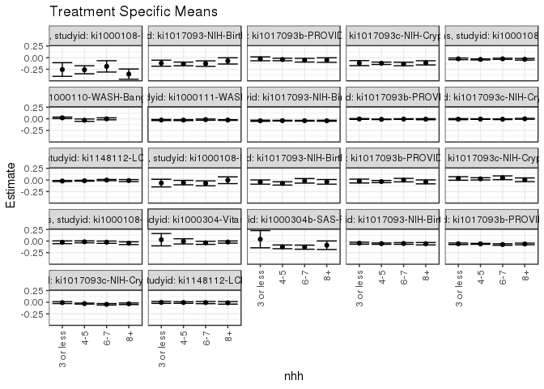

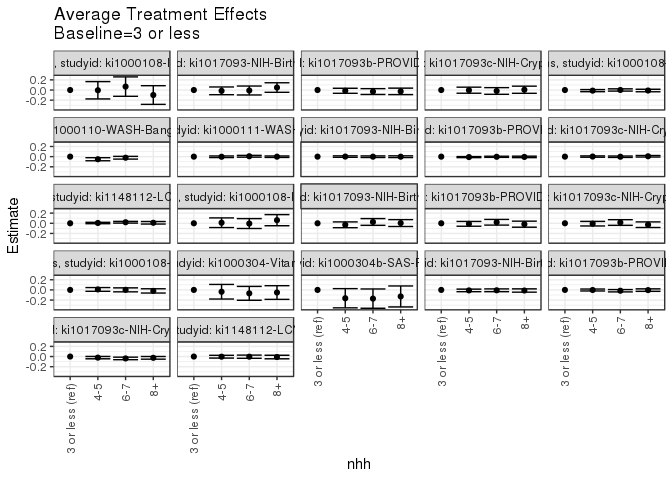

## Results Table

### Parameter: TSM

| diffcat | studyid | country | intervention_level | baseline_level | estimate | ci_lower | ci_upper |
| --- | --- | --- | --- | --- | --- | --- | --- |
| 0-3 months | ki1000108-IRC | INDIA | 3 or less | NA | -0.2546692 | -0.4020239 | -0.1073144 |
| 0-3 months | ki1000108-IRC | INDIA | 4-5 | NA | -0.2594418 | -0.3455000 | -0.1733835 |
| 0-3 months | ki1000108-IRC | INDIA | 6-7 | NA | -0.1872275 | -0.3092502 | -0.0652048 |
| 0-3 months | ki1000108-IRC | INDIA | 8+ | NA | -0.3534005 | -0.4634050 | -0.2433960 |
| 0-3 months | ki1017093-NIH-Birth | BANGLADESH | 3 or less | NA | -0.1182345 | -0.1833800 | -0.0530891 |
| 0-3 months | ki1017093-NIH-Birth | BANGLADESH | 4-5 | NA | -0.1343925 | -0.1736014 | -0.0951836 |
| 0-3 months | ki1017093-NIH-Birth | BANGLADESH | 6-7 | NA | -0.1276316 | -0.1865972 | -0.0686661 |
| 0-3 months | ki1017093-NIH-Birth | BANGLADESH | 8+ | NA | -0.0692667 | -0.1364275 | -0.0021060 |
| 0-3 months | ki1017093b-PROVIDE | BANGLADESH | 3 or less | NA | -0.0245411 | -0.0660283 | 0.0169461 |
| 0-3 months | ki1017093b-PROVIDE | BANGLADESH | 4-5 | NA | -0.0393529 | -0.0661390 | -0.0125668 |
| 0-3 months | ki1017093b-PROVIDE | BANGLADESH | 6-7 | NA | -0.0546672 | -0.0941664 | -0.0151680 |
| 0-3 months | ki1017093b-PROVIDE | BANGLADESH | 8+ | NA | -0.0510935 | -0.0995256 | -0.0026615 |
| 0-3 months | ki1017093c-NIH-Crypto | BANGLADESH | 3 or less | NA | -0.1171054 | -0.1712058 | -0.0630051 |
| 0-3 months | ki1017093c-NIH-Crypto | BANGLADESH | 4-5 | NA | -0.1207461 | -0.1462781 | -0.0952141 |
| 0-3 months | ki1017093c-NIH-Crypto | BANGLADESH | 6-7 | NA | -0.1355042 | -0.1730816 | -0.0979269 |
| 0-3 months | ki1017093c-NIH-Crypto | BANGLADESH | 8+ | NA | -0.1112240 | -0.1562130 | -0.0662350 |
| 3-6 months | ki1000108-IRC | INDIA | 3 or less | NA | -0.0675296 | -0.1496225 | 0.0145633 |
| 3-6 months | ki1000108-IRC | INDIA | 4-5 | NA | -0.0567931 | -0.1046158 | -0.0089703 |
| 3-6 months | ki1000108-IRC | INDIA | 6-7 | NA | -0.0727749 | -0.1250467 | -0.0205031 |
| 3-6 months | ki1000108-IRC | INDIA | 8+ | NA | -0.0061435 | -0.0791299 | 0.0668429 |
| 3-6 months | ki1017093-NIH-Birth | BANGLADESH | 3 or less | NA | -0.0451535 | -0.0901732 | -0.0001338 |
| 3-6 months | ki1017093-NIH-Birth | BANGLADESH | 4-5 | NA | -0.0750228 | -0.1099796 | -0.0400660 |
| 3-6 months | ki1017093-NIH-Birth | BANGLADESH | 6-7 | NA | -0.0191869 | -0.0678666 | 0.0294929 |
| 3-6 months | ki1017093-NIH-Birth | BANGLADESH | 8+ | NA | -0.0406444 | -0.0908712 | 0.0095824 |
| 3-6 months | ki1017093b-PROVIDE | BANGLADESH | 3 or less | NA | -0.0241209 | -0.0657276 | 0.0174859 |
| 3-6 months | ki1017093b-PROVIDE | BANGLADESH | 4-5 | NA | -0.0349136 | -0.0578027 | -0.0120244 |
| 3-6 months | ki1017093b-PROVIDE | BANGLADESH | 6-7 | NA | -0.0039961 | -0.0415279 | 0.0335357 |
| 3-6 months | ki1017093b-PROVIDE | BANGLADESH | 8+ | NA | -0.0417289 | -0.0841267 | 0.0006688 |
| 3-6 months | ki1017093c-NIH-Crypto | BANGLADESH | 3 or less | NA | 0.0314652 | -0.0065418 | 0.0694722 |
| 3-6 months | ki1017093c-NIH-Crypto | BANGLADESH | 4-5 | NA | 0.0235468 | -0.0003394 | 0.0474329 |

[output cut: 57 more lines]

### Parameter: E(Y)

| diffcat | studyid | country | intervention_level | baseline_level | estimate | ci_lower | ci_upper |
| --- | --- | --- | --- | --- | --- | --- | --- |
| 0-3 months | ki1000108-IRC | INDIA | NA | NA | -0.2594964 | -0.3154509 | -0.2035418 |
| 0-3 months | ki1017093-NIH-Birth | BANGLADESH | NA | NA | -0.1191165 | -0.1460676 | -0.0921654 |
| 0-3 months | ki1017093b-PROVIDE | BANGLADESH | NA | NA | -0.0413143 | -0.0594662 | -0.0231624 |
| 0-3 months | ki1017093c-NIH-Crypto | BANGLADESH | NA | NA | -0.1220821 | -0.1402761 | -0.1038881 |
| 3-6 months | ki1000108-IRC | INDIA | NA | NA | -0.0518918 | -0.0819849 | -0.0217987 |
| 3-6 months | ki1017093-NIH-Birth | BANGLADESH | NA | NA | -0.0509007 | -0.0730097 | -0.0287917 |
| 3-6 months | ki1017093b-PROVIDE | BANGLADESH | NA | NA | -0.0272428 | -0.0436954 | -0.0107902 |
| 3-6 months | ki1017093c-NIH-Crypto | BANGLADESH | NA | NA | 0.0267740 | 0.0099602 | 0.0435879 |
| 6-12 months | ki1000108-IRC | INDIA | NA | NA | -0.0260151 | -0.0389122 | -0.0131180 |
| 6-12 months | ki1000304-Vitamin-B12 | INDIA | NA | NA | -0.0184659 | -0.0429764 | 0.0060446 |
| 6-12 months | ki1000304b-SAS-FoodSuppl | INDIA | NA | NA | -0.1080113 | -0.1390238 | -0.0769988 |
| 6-12 months | ki1017093-NIH-Birth | BANGLADESH | NA | NA | -0.0530976 | -0.0624028 | -0.0437924 |
| 6-12 months | ki1017093b-PROVIDE | BANGLADESH | NA | NA | -0.0626151 | -0.0695574 | -0.0556729 |
| 6-12 months | ki1017093c-NIH-Crypto | BANGLADESH | NA | NA | -0.0315658 | -0.0388594 | -0.0242722 |
| 6-12 months | ki1148112-LCNI-5 | MALAWI | NA | NA | -0.0067938 | -0.0177737 | 0.0041862 |
| 12-24 months | ki1000108-IRC | INDIA | NA | NA | -0.0317687 | -0.0388357 | -0.0247017 |
| 12-24 months | ki1000110-WASH-Bangladesh | BANGLADESH | NA | NA | -0.0026893 | -0.0170438 | 0.0116652 |
| 12-24 months | ki1000111-WASH-Kenya | KENYA | NA | NA | -0.0245505 | -0.0298472 | -0.0192538 |
| 12-24 months | ki1017093-NIH-Birth | BANGLADESH | NA | NA | -0.0404278 | -0.0450901 | -0.0357656 |
| 12-24 months | ki1017093b-PROVIDE | BANGLADESH | NA | NA | -0.0081718 | -0.0120131 | -0.0043304 |
| 12-24 months | ki1017093c-NIH-Crypto | BANGLADESH | NA | NA | -0.0057326 | -0.0097260 | -0.0017391 |
| 12-24 months | ki1148112-LCNI-5 | MALAWI | NA | NA | -0.0160605 | -0.0218715 | -0.0102495 |

### Parameter: ATE

| diffcat | studyid | country | intervention_level | baseline_level | estimate | ci_lower | ci_upper |
| --- | --- | --- | --- | --- | --- | --- | --- |
| 0-3 months | ki1000108-IRC | INDIA | 3 or less | 3 or less | 0.0000000 | 0.0000000 | 0.0000000 |
| 0-3 months | ki1000108-IRC | INDIA | 4-5 | 3 or less | -0.0047726 | -0.1754169 | 0.1658716 |
| 0-3 months | ki1000108-IRC | INDIA | 6-7 | 3 or less | 0.0674416 | -0.1238774 | 0.2587607 |
| 0-3 months | ki1000108-IRC | INDIA | 8+ | 3 or less | -0.0987313 | -0.2826183 | 0.0851557 |
| 0-3 months | ki1017093-NIH-Birth | BANGLADESH | 3 or less | 3 or less | 0.0000000 | 0.0000000 | 0.0000000 |
| 0-3 months | ki1017093-NIH-Birth | BANGLADESH | 4-5 | 3 or less | -0.0161580 | -0.0921927 | 0.0598767 |
| 0-3 months | ki1017093-NIH-Birth | BANGLADESH | 6-7 | 3 or less | -0.0093971 | -0.0972656 | 0.0784713 |
| 0-3 months | ki1017093-NIH-Birth | BANGLADESH | 8+ | 3 or less | 0.0489678 | -0.0445977 | 0.1425333 |
| 0-3 months | ki1017093b-PROVIDE | BANGLADESH | 3 or less | 3 or less | 0.0000000 | 0.0000000 | 0.0000000 |
| 0-3 months | ki1017093b-PROVIDE | BANGLADESH | 4-5 | 3 or less | -0.0148118 | -0.0641948 | 0.0345712 |
| 0-3 months | ki1017093b-PROVIDE | BANGLADESH | 6-7 | 3 or less | -0.0301261 | -0.0874094 | 0.0271572 |
| 0-3 months | ki1017093b-PROVIDE | BANGLADESH | 8+ | 3 or less | -0.0265525 | -0.0903243 | 0.0372194 |
| 0-3 months | ki1017093c-NIH-Crypto | BANGLADESH | 3 or less | 3 or less | 0.0000000 | 0.0000000 | 0.0000000 |
| 0-3 months | ki1017093c-NIH-Crypto | BANGLADESH | 4-5 | 3 or less | -0.0036407 | -0.0634632 | 0.0561818 |
| 0-3 months | ki1017093c-NIH-Crypto | BANGLADESH | 6-7 | 3 or less | -0.0183988 | -0.0842692 | 0.0474716 |
| 0-3 months | ki1017093c-NIH-Crypto | BANGLADESH | 8+ | 3 or less | 0.0058814 | -0.0644809 | 0.0762438 |
| 3-6 months | ki1000108-IRC | INDIA | 3 or less | 3 or less | 0.0000000 | 0.0000000 | 0.0000000 |
| 3-6 months | ki1000108-IRC | INDIA | 4-5 | 3 or less | 0.0107365 | -0.0842701 | 0.1057431 |
| 3-6 months | ki1000108-IRC | INDIA | 6-7 | 3 or less | -0.0052453 | -0.1025674 | 0.0920767 |
| 3-6 months | ki1000108-IRC | INDIA | 8+ | 3 or less | 0.0613861 | -0.0484604 | 0.1712326 |
| 3-6 months | ki1017093-NIH-Birth | BANGLADESH | 3 or less | 3 or less | 0.0000000 | 0.0000000 | 0.0000000 |
| 3-6 months | ki1017093-NIH-Birth | BANGLADESH | 4-5 | 3 or less | -0.0298693 | -0.0868671 | 0.0271285 |
| 3-6 months | ki1017093-NIH-Birth | BANGLADESH | 6-7 | 3 or less | 0.0259667 | -0.0403393 | 0.0922727 |
| 3-6 months | ki1017093-NIH-Birth | BANGLADESH | 8+ | 3 or less | 0.0045091 | -0.0629409 | 0.0719591 |
| 3-6 months | ki1017093b-PROVIDE | BANGLADESH | 3 or less | 3 or less | 0.0000000 | 0.0000000 | 0.0000000 |
| 3-6 months | ki1017093b-PROVIDE | BANGLADESH | 4-5 | 3 or less | -0.0107927 | -0.0582799 | 0.0366945 |
| 3-6 months | ki1017093b-PROVIDE | BANGLADESH | 6-7 | 3 or less | 0.0201248 | -0.0359088 | 0.0761583 |
| 3-6 months | ki1017093b-PROVIDE | BANGLADESH | 8+ | 3 or less | -0.0176081 | -0.0770109 | 0.0417947 |
| 3-6 months | ki1017093c-NIH-Crypto | BANGLADESH | 3 or less | 3 or less | 0.0000000 | 0.0000000 | 0.0000000 |
| 3-6 months | ki1017093c-NIH-Crypto | BANGLADESH | 4-5 | 3 or less | -0.0079184 | -0.0528080 | 0.0369712 |

[output cut: 57 more lines]